# Estimate parameters in a PBPK model

Metrum Research Group

# 1 Packages and setup

```r
library(tidyverse)
library(mrgsolve)
library(PKPDmisc)
library(minqa)
library(DEoptim)
library(GenSA)
library(hydroPSO)
library(here)
source(here("day1/src/functions.R"))

set.seed(10101)

theme_set(theme_bw())
theme_update(legend.position = "top")
scale_colour_discrete <- function(...) scale_color_brewer(palette="Set2")
```

Models are located here:

```r
model_dir <- here("day1/model")
```

# 2 Reference

**Quantitative Analyses of Hepatic OATP-Mediated Interactions Between Statins and Inhibitors Using PBPK Modeling With a Parameter Optimization Method**

- T Yoshikado, K Yoshida, N Kotani, T Nakada, R Asaumi, K Toshimoto, K Maeda, H Kusuhara and Y Sugiyama
- CLINICAL PHARMACOLOGY & THERAPEUTICS | VOLUME 100 NUMBER 5 | NOVEMBER 2016
- https://www.ncbi.nlm.nih.gov/pubmed/27170342

# 3 Data

- Example taken from figure 4a from the publication
- Using this as example data to fit

```r
data.file <- here("day1/data/fig4a.csv")

data <-
  data.file %>%
  read_csv() %>%
  mutate(
    profile = NULL,
    type=ID,
    typef=factor(ID, labels = c("Statin", "Statin+CsA"))
  )
```

- The goal is to fit the pitavastatin data either alone (left) or in combination with cyclosporin administered 1 hour before the pitavastatin

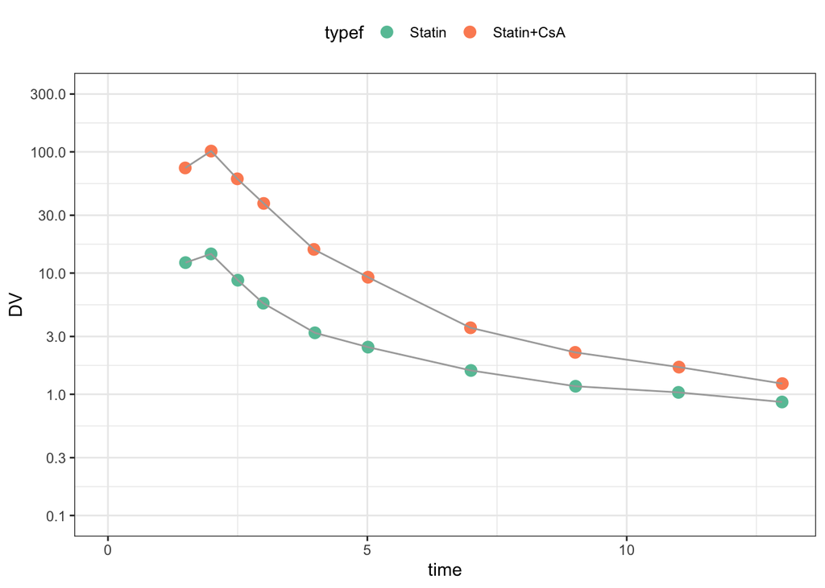

```r
ggplot(data=data,aes(time,DV)) +
  geom_point(aes(col = typef), size = 3) +
  geom_line(col = "darkgrey", aes(group = typef)) +
  scale_y_continuous(trans="log", limits=c(0.1,300), breaks=logbr())
```

- Pick out the doses and the observations

```r
dose <- filter(data,evid==1) %>% mutate(typef=NULL)

dose
```

```
. # A tibble: 3 × 7
.      ID  time    DV  evid   amt   cmt  type
.   <dbl> <dbl> <dbl> <dbl> <dbl> <dbl> <dbl>
. 1     2     0    -1     1  2000     2     2
. 2     2     1    -1     1    30     1     2
. 3     1     1    -1     1    30     1     1
```

```r
yobs <- filter(data,evid==0) %>% dplyr::select(DV) %>% unlist %>% unname

yobs
```

```
.  [1]  73.707 101.538  59.936  37.558  15.684   9.243   3.538   2.217   1.676
. [10]   1.225  12.198  14.400   8.736   5.644   3.215   2.450   1.572   1.165
. [19]   1.037   0.864
```

```r
data <-  dplyr::select(data, -typef)
```

# 4 PBPK model: pitavastatin / CsA DDI

- Check out the model / data with a quick simulation
- We’re only interested in `CP`, the pitavastatin concentration

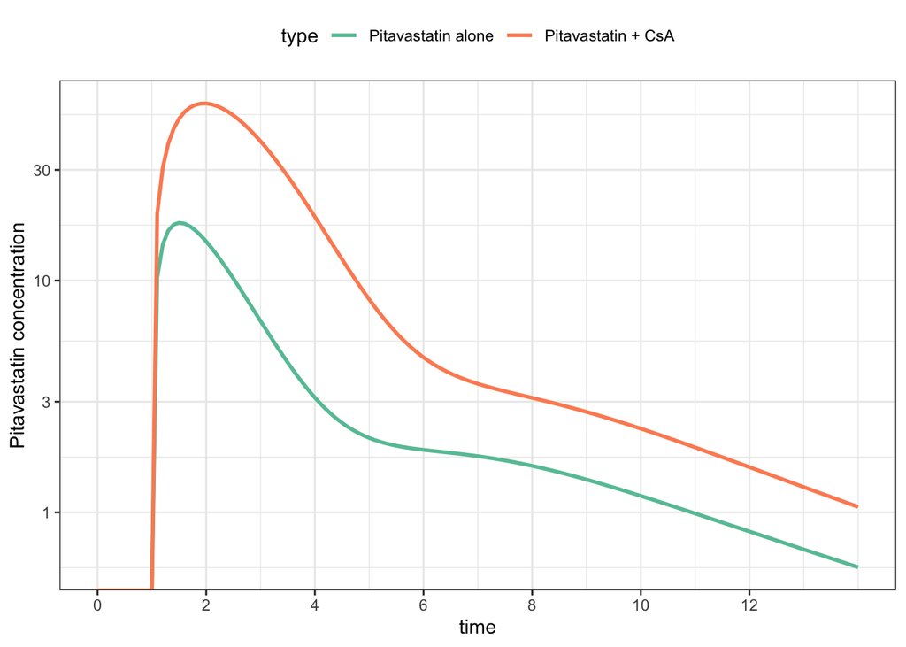

```r
mod <- mread_cache("yoshikado", model_dir) %>%
  update(end=14, delta=0.1) %>%
  Req(CP) %>%
  obsonly()

sims <-
  mod %>%
  mrgsim(data=dose,obsaug=TRUE) %>%
  mutate(type = typef(ID))

ggplot(sims, aes(time,CP,col=type)) +
  geom_line(lwd = 1) +
  scale_x_continuous(breaks = seq(0,12,2)) +
  scale_y_continuous(trans = "log10", name = "Pitavastatin concentration")
```

```r
sims %>%
  group_by(type) %>%
  summarise(auc = auc_partial(time,CP)) %>%
  mutate(fold_increase = auc /first(auc))
```

```
. # A tibble: 2 × 3
.   type                 auc fold_increase
.   <fct>              <dbl>         <dbl>
. 1 Pitavastatin alone  44.1          1
. 2 Pitavastatin + CsA 161.           3.65
```

# 5 Objective function

- Least squares objective function
- Weighted by the observations

```r
wss <- function(dv, pred, par=NULL) {
  sum(((dv-pred)/dv)^2) ## dnorm(yobs, yhat, sd, log = TRUE)
}
```

### 5.0.1 Prediction function

- Let’s go through step by step what each line is doing for us

```r
pred <- function(p, .data, yobs=NULL, pred=FALSE) {

  .par <- lapply(p,exp) %>% setNames(names(theta))

  .mod <- param(mod,.par)

  if(pred) {
    out <- mrgsim(.mod,data=.data,carry.out="type")
    return(as_tibble(out))
  }

  out <- mrgsim(.mod, data=.data, obsonly=TRUE, Req="CP")

  return(wss(yobs,out$CP))

  #return(-1*sum(dnorm(log(yobs),log(out$CP),.par$sigma,log=TRUE)))

}
```

# 6 Optimize with different methods

## 6.1 `minqa::newuoa`: minimization without derivatives

- These appear to be the parameters that the authors are fitting

```r
theta <- log(c(fbCLintall = 1.2, ikiu = 1.2,
               fbile = 0.9, ka = 0.1, ktr = 0.1))

control <- list(iprint=25)

fit1 <- newuoa(theta, pred,.data=data, yobs=yobs,control=control)
```

```
. npt = 7 , n =  5
. rhobeg =  0.460517 , rhoend =  4.60517e-07
. start par. =  0.1823216 0.1823216 -0.1053605 -2.302585 -2.302585 fn =  11.02654
. rho:    0.046 eval:   8 fn:      7.75648 par:-0.278195 0.182322 -0.105361 -2.30259 -2.30259
.  25:     5.9761208: -0.384231 0.0362187 0.00414864 -1.21552 -2.32950
.  50:     5.2910644: -0.320447 -0.00894289 -0.0870670 -0.983963 -1.75854
.  75:     4.5645497: -0.328951 -0.743801 -1.06774 -0.118327 -0.592978
. 100:     4.3520123: -0.303163 -1.20647 -0.997201 -0.176759 -0.398081
. rho:   0.0046 eval: 102 fn:      4.34500 par:-0.305714 -1.23524 -1.00252 -0.158812 -0.384061
. 125:     4.2810223: -0.316638 -1.54245 -0.997561 -0.156405 -0.279816
. 150:     3.9385388: -0.268047 -2.09420 -0.944923 -0.155501 -0.283843
. 175:     1.2097307: -0.140025 -4.09539 -0.874200 0.128840 -0.00930516
. 200:    0.79666221: -0.134254 -4.50134 -0.939284 0.185529 -0.0927621
. 225:    0.72763191: -0.163598 -4.54226 -0.998478 0.119235 -0.216891
. 250:    0.69316408: -0.192053 -4.51353 -1.03745 0.0203543 -0.307270
. rho:  0.00046 eval: 264 fn:     0.686293 par:-0.203990 -4.50776 -1.06410 -0.00837765 -0.363096
. 275:    0.68614482: -0.205448 -4.51165 -1.06659 -0.00955244 -0.368663
. 300:    0.68607714: -0.204161 -4.51426 -1.06737 -0.0107453 -0.370787
. rho:  4.6e-05 eval: 300 fn:     0.686077 par:-0.204147 -4.51433 -1.06737 -0.0109877 -0.371172
. rho:  4.6e-06 eval: 310 fn:     0.686077 par:-0.204154 -4.51437 -1.06741 -0.0110370 -0.371157
. rho:  4.6e-07 eval: 319 fn:     0.686077 par:-0.204154 -4.51437 -1.06741 -0.0110370 -0.371157
. 325:    0.68607657: -0.204154 -4.51437 -1.06741 -0.0110376 -0.371157
. At return
. eval: 329 fn:     0.68607651 par: -0.204154 -4.51437 -1.06741 -0.0110372 -0.371157
```

```r
fit1$par <- setNames(fit1$par,names(theta))
```

### 6.1.1 Get some predictions to look at how the fit went

- Predictions with the final estimates
- Predications with the initial estimates
- Observed data to overlay

```r
df_pred <- pred(fit1$par,dose,pred=TRUE) %>% mutate(type = typef(type))
df_init <- pred(theta,dose,pred=TRUE) %>% mutate(type = typef(type))
df_obs <- mutate(data, type=typef(type))
```

### 6.1.2 Plot

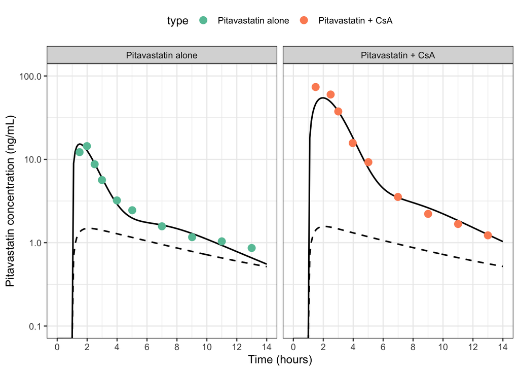

```r
ggplot(data=df_pred) +
  geom_line(data=df_init,aes(time,CP,lty="A"), col="black", lwd=0.7) +
  geom_line(aes(time,CP,lty="B"),col="black",lwd=0.7) +
  geom_point(data=df_obs,aes(time,DV,col=type),size=3) +
  facet_wrap(~type) +
  scale_y_continuous(trans="log",breaks=10^seq(-4,4),
                     limits=c(0.1,100),
                     "Pitavastatin concentration (ng/mL)") +
  scale_x_continuous(name="Time (hours)", breaks=seq(0,14,2)) +
  scale_linetype_manual(values= c(2,1), guide = FALSE,
                        labels=c("Initial estimates", "Final estimates"), name="") +
  theme_bw() + theme(legend.position="top")
```

### 6.1.3 The final objective function value and estimates

```r
pred(fit1$par,.data=data,yobs=yobs)
```

```
. [1] 0.6860765
```

```r
exp(fit1$par)
```

```
. fbCLintall       ikiu      fbile         ka        ktr
. 0.81533659 0.01095046 0.34389904 0.98902349 0.68993549
```

## 6.2 `optim`: Nelder-Mead

```r
fit1b <- optim(theta, pred,.data=data, yobs=yobs)
```

## 6.3 `DEoptim`: differential evolution algorithm

“Performs evolutionary global optimization via the Differential Evolution algorithm.”

```r
lower <- rep(-6,length(theta)) %>% setNames(names(theta))
upper <- rep(5, length(theta)) %>% setNames(names(theta))

set.seed(330303)

decontrol <- DEoptim.control(
  NP=10*length(theta),
  CR=0.925,
  F=0.85,
  itermax=90,
  storepopfrom=0
)

fit2 <- DEoptim(
  fn=pred,
  lower=lower,
  upper=upper,
  control=decontrol,
  .data=data,
  yobs=yobs
)
```

```
. Iteration: 1 bestvalit: 3.595057 bestmemit:   -0.134601   -4.736514   -1.124463   -1.499637   -2.042640
. Iteration: 2 bestvalit: 3.595057 bestmemit:   -0.134601   -4.736514   -1.124463   -1.499637   -2.042640
. Iteration: 3 bestvalit: 3.595057 bestmemit:   -0.134601   -4.736514   -1.124463   -1.499637   -2.042640
. Iteration: 4 bestvalit: 3.595057 bestmemit:   -0.134601   -4.736514   -1.124463   -1.499637   -2.042640
. Iteration: 5 bestvalit: 3.595057 bestmemit:   -0.134601   -4.736514   -1.124463   -1.499637   -2.042640
. Iteration: 6 bestvalit: 3.595057 bestmemit:   -0.134601   -4.736514   -1.124463   -1.499637   -2.042640
. Iteration: 7 bestvalit: 3.315578 bestmemit:   -0.201211   -4.336813   -1.281470   -1.438331   -1.486157
. Iteration: 8 bestvalit: 3.315578 bestmemit:   -0.201211   -4.336813   -1.281470   -1.438331   -1.486157
. Iteration: 9 bestvalit: 3.315578 bestmemit:   -0.201211   -4.336813   -1.281470   -1.438331   -1.486157
. Iteration: 10 bestvalit: 2.359438 bestmemit:    0.090828   -4.810051   -1.032300   -0.596372   -0.748306
. Iteration: 11 bestvalit: 2.359438 bestmemit:    0.090828   -4.810051   -1.032300   -0.596372   -0.748306
. Iteration: 12 bestvalit: 2.359438 bestmemit:    0.090828   -4.810051   -1.032300   -0.596372   -0.748306
. Iteration: 13 bestvalit: 2.359438 bestmemit:    0.090828   -4.810051   -1.032300   -0.596372   -0.748306
. Iteration: 14 bestvalit: 2.359438 bestmemit:    0.090828   -4.810051   -1.032300   -0.596372   -0.748306
. Iteration: 15 bestvalit: 2.359438 bestmemit:    0.090828   -4.810051   -1.032300   -0.596372   -0.748306
. Iteration: 16 bestvalit: 2.359438 bestmemit:    0.090828   -4.810051   -1.032300   -0.596372   -0.748306
. Iteration: 17 bestvalit: 2.359438 bestmemit:    0.090828   -4.810051   -1.032300   -0.596372   -0.748306
. Iteration: 18 bestvalit: 2.359438 bestmemit:    0.090828   -4.810051   -1.032300   -0.596372   -0.748306
. Iteration: 19 bestvalit: 2.359438 bestmemit:    0.090828   -4.810051   -1.032300   -0.596372   -0.748306
. Iteration: 20 bestvalit: 2.359438 bestmemit:    0.090828   -4.810051   -1.032300   -0.596372   -0.748306
. Iteration: 21 bestvalit: 2.359438 bestmemit:    0.090828   -4.810051   -1.032300   -0.596372   -0.748306
. Iteration: 22 bestvalit: 2.359438 bestmemit:    0.090828   -4.810051   -1.032300   -0.596372   -0.748306
. Iteration: 23 bestvalit: 2.359438 bestmemit:    0.090828   -4.810051   -1.032300   -0.596372   -0.748306
. Iteration: 24 bestvalit: 2.359438 bestmemit:    0.090828   -4.810051   -1.032300   -0.596372   -0.748306
. Iteration: 25 bestvalit: 2.288685 bestmemit:   -0.056797   -4.270735   -0.690835    0.395834    0.806163
. Iteration: 26 bestvalit: 2.148635 bestmemit:   -0.065283   -4.028912   -0.946511   -0.362810    0.418513
. Iteration: 27 bestvalit: 1.503889 bestmemit:   -0.113360   -4.810051   -1.032300   -0.596372   -0.851621
. Iteration: 28 bestvalit: 1.503889 bestmemit:   -0.113360   -4.810051   -1.032300   -0.596372   -0.851621
. Iteration: 29 bestvalit: 1.433728 bestmemit:   -0.180772   -4.655892   -1.310720    0.157489   -0.438752
. Iteration: 30 bestvalit: 0.745879 bestmemit:   -0.220189   -4.444982   -1.045812   -0.135432   -0.454597
. Iteration: 31 bestvalit: 0.745879 bestmemit:   -0.220189   -4.444982   -1.045812   -0.135432   -0.454597
. Iteration: 32 bestvalit: 0.745879 bestmemit:   -0.220189   -4.444982   -1.045812   -0.135432   -0.454597
. Iteration: 33 bestvalit: 0.745879 bestmemit:   -0.220189   -4.444982   -1.045812   -0.135432   -0.454597
. Iteration: 34 bestvalit: 0.745879 bestmemit:   -0.220189   -4.444982   -1.045812   -0.135432   -0.454597
. Iteration: 35 bestvalit: 0.745879 bestmemit:   -0.220189   -4.444982   -1.045812   -0.135432   -0.454597
. Iteration: 36 bestvalit: 0.745879 bestmemit:   -0.220189   -4.444982   -1.045812   -0.135432   -0.454597
. Iteration: 37 bestvalit: 0.745879 bestmemit:   -0.220189   -4.444982   -1.045812   -0.135432   -0.454597
. Iteration: 38 bestvalit: 0.745879 bestmemit:   -0.220189   -4.444982   -1.045812   -0.135432   -0.454597
. Iteration: 39 bestvalit: 0.733471 bestmemit:   -0.201757   -4.500855   -1.075498   -0.170296   -0.414804
. Iteration: 40 bestvalit: 0.733471 bestmemit:   -0.201757   -4.500855   -1.075498   -0.170296   -0.414804
```

[output cut: 35 more lines]

```
. Iteration: 76 bestvalit: 0.686256 bestmemit:   -0.201066   -4.514154   -1.064211   -0.006224   -0.361932
. Iteration: 77 bestvalit: 0.686163 bestmemit:   -0.204085   -4.514142   -1.067557   -0.014984   -0.367346
. Iteration: 78 bestvalit: 0.686121 bestmemit:   -0.203278   -4.514187   -1.064788   -0.010720   -0.370142
. Iteration: 79 bestvalit: 0.686121 bestmemit:   -0.203278   -4.514187   -1.064788   -0.010720   -0.370142
. Iteration: 80 bestvalit: 0.686121 bestmemit:   -0.203278   -4.514187   -1.064788   -0.010720   -0.370142
. Iteration: 81 bestvalit: 0.686121 bestmemit:   -0.203278   -4.514187   -1.064788   -0.010720   -0.370142
. Iteration: 82 bestvalit: 0.686121 bestmemit:   -0.203278   -4.514187   -1.064788   -0.010720   -0.370142
. Iteration: 83 bestvalit: 0.686081 bestmemit:   -0.204019   -4.514555   -1.067274   -0.011397   -0.372682
. Iteration: 84 bestvalit: 0.686081 bestmemit:   -0.204019   -4.514555   -1.067274   -0.011397   -0.372682
. Iteration: 85 bestvalit: 0.686081 bestmemit:   -0.204019   -4.514555   -1.067274   -0.011397   -0.372682
. Iteration: 86 bestvalit: 0.686081 bestmemit:   -0.204019   -4.514555   -1.067274   -0.011397   -0.372682
. Iteration: 87 bestvalit: 0.686081 bestmemit:   -0.204019   -4.514555   -1.067274   -0.011397   -0.372682
. Iteration: 88 bestvalit: 0.686081 bestmemit:   -0.204019   -4.514555   -1.067274   -0.011397   -0.372682
. Iteration: 89 bestvalit: 0.686081 bestmemit:   -0.204019   -4.514555   -1.067274   -0.011397   -0.372682
. Iteration: 90 bestvalit: 0.686081 bestmemit:   -0.204019   -4.514555   -1.067274   -0.011397   -0.372682
```

### 6.3.1 DA for the plot

```r
pops <- lapply(fit2$member$storepop, as.data.frame)
hx <- bind_rows(pops)
hx <- mutate(hx, iteration=rep(1:decontrol$itermax,each=decontrol$NP))
hx <- mutate(hx, pop = rep(1:decontrol$NP, time=decontrol$itermax))
hxm <- gather(hx, variable, value, 1:5) %>% mutate(value = exp(value))
best <- as_tibble(fit2$member$bestmemit) %>%
  mutate(iteration = 1:decontrol$itermax)
bestm <- gather(best,variable,value,1:5) %>% mutate(value = exp(value))
```

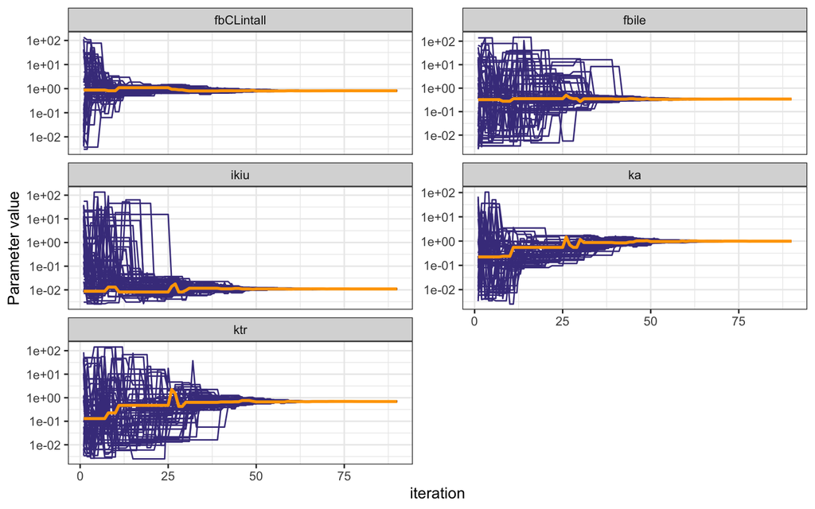

```r
ggplot(data=hxm) +
  geom_line(aes(iteration,value,group=pop),col="darkslateblue") +
  geom_line(data=bestm,aes(iteration,value),col="orange",lwd=1) +
  scale_y_continuous(trans="log", breaks=10^seq(-4,4), name="Parameter value") +
  facet_wrap(~variable, ncol=2, scales="free_y") + theme_bw()
```

## 6.4 `GenSA`: simulated annealing

```r
set.seed(11001)

sacontrol <- list(maxit = 100, nb.stop.improvement = 20, verbose = TRUE)

fit3 <- GenSA(
  NULL, pred, lower + 0.5, upper - 0.5, .data = data, yobs = yobs,
  control = sacontrol
)
```

```
. Initializing par with random data inside bounds
. It: 1, obj value: 3.473880779
. It: 44, obj value: 0.686086256
```

# 7 Compare optimization methods

```r
results <- list(theta, fit1$par, fit1b$par, fit2$optim$bestmem, fit3$par)

results <- map(results, exp)

tibble(
  method = c("initial", "newuoa", "nelder", "DEoptim", "SA"),
  fbCLintall = map_dbl(results, "fbCLintall"),
  ikiu = map_dbl(results, "ikiu"),
  fbile = map_dbl(results, "fbile"),
  ka = map_dbl(results, "ka"),
  ktr = map_dbl(results, "ktr")
) %>%  knitr::kable(digits = 4)
```

| method | fbCLintall | ikiu | fbile | ka | ktr |
| --- | --- | --- | --- | --- | --- |
| initial | 1.2000 | 1.2000 | 0.9000 | 0.1000 | 0.1000 |
| newuoa | 0.8153 | 0.0110 | 0.3439 | 0.9890 | 0.6899 |
| nelder | 0.8387 | 0.0106 | 0.3572 | 0.9904 | 0.7114 |
| DEoptim | 0.8154 | 0.0109 | 0.3439 | 0.9887 | 0.6889 |
| SA | 0.8146 | 0.0110 | 0.3434 | 0.9880 | 0.6893 |